# Introduction to R

## 8.2 Scatter Plots

The default of `plot` functions is Scatter plot.

|  | X | state | abb | region | population | PopulationDensity | murders | gunmurders | gunownership |
| --- | --- | --- | --- | --- | --- | --- | --- | --- | --- |
| 1 | 0 | Alabama | AL | South | 4779736 | 94.65 | 199 | 135 | 0.517 |
| 2 | 1 | Arizona | AZ | West | 6392017 | 57.05 | 352 | 232 | 0.311 |
| 3 | 2 | California | CA | West | 37253956 | 244.20 | 1811 | 1257 | 0.213 |
| 4 | 3 | Colorado | CO | West | 5029196 | 49.33 | 117 | 65 | 0.347 |
| 5 | 4 | Connecticut | CT | Northeast | 3574097 | 741.40 | 131 | 97 | 0.167 |
| 6 | 5 | Florida | FL | South | 19687653 | 360.20 | 987 | 669 | 0.245 |

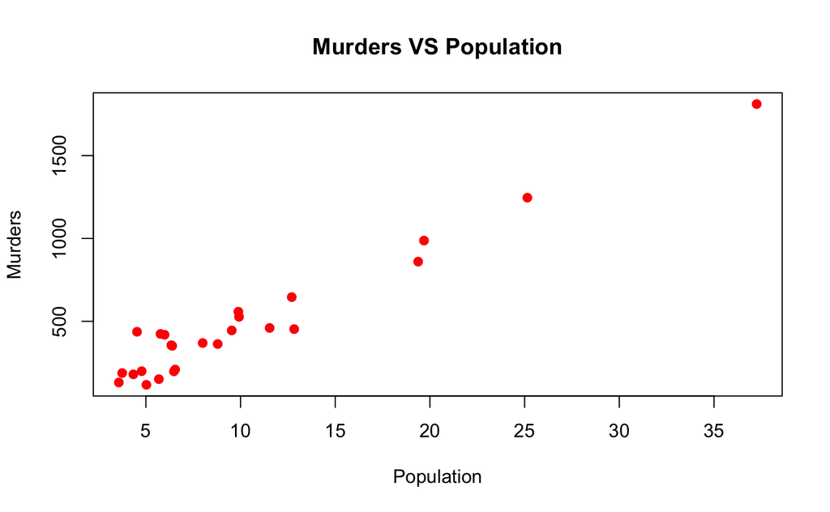

```r
plot(df$population / 10^6, df$murders,
        col = 'red',
        xlab = 'Population',
        ylab = 'Murders',
        main = 'Murders VS Population',
        pch = 19
     )
```

**pch values**

Values of pch are stored internally as integers.

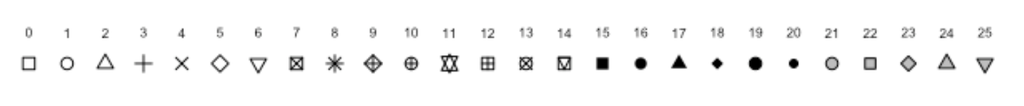

Some values of pch

## 8.3 Line Graphs

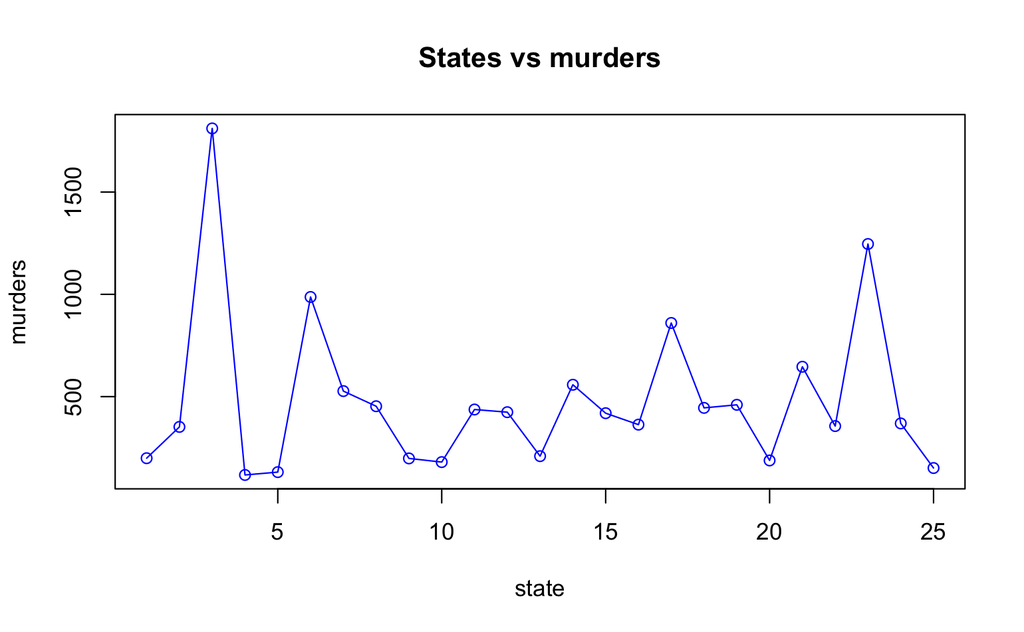

**`type` in `plot` function**

- **“p”** for points,
- **“l”** for lines,
- **“b”** for both points and lines,
- **“c”** for empty points joined by lines,
- **“o”** for overplotted points and lines,
- **“s”** and **“S”** for stair steps,
- **“h”** for histogram-like vertical lines,
- **“n”** does not produce any points or lines.

## 8.4 Box plots

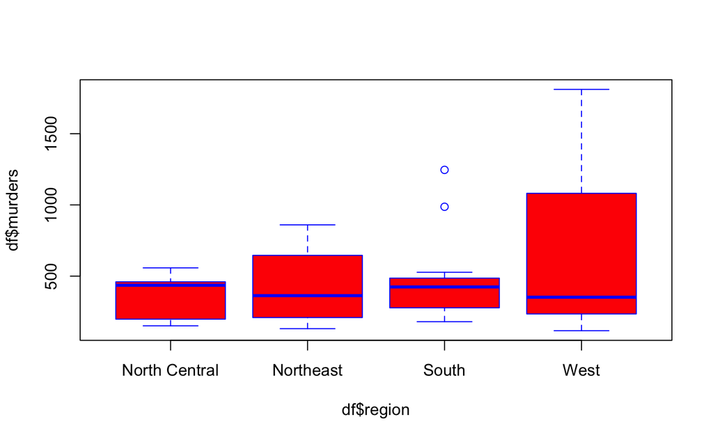

## 8.5 Multiple Plots in Layout

[figure not shown]

```r
par(mfrow = c(1,2))

barplot(df$population, col = 'blue')

barplot(df$murders, col= 'red')
```

# 9 Regressions and Models

## 9.1 Simple Linear Regression

Linear regression is used to model the relationship between a dependent variable and one or more independent variables by fitting a line through the data.

| X | state | abb | region | population | PopulationDensity | murders | gunmurders | gunownership |
| --- | --- | --- | --- | --- | --- | --- | --- | --- |
| 0 | Alabama | AL | South | 4779736 | 94.65 | 199 | 135 | 0.517 |
| 1 | Arizona | AZ | West | 6392017 | 57.05 | 352 | 232 | 0.311 |
| 2 | California | CA | West | 37253956 | 244.20 | 1811 | 1257 | 0.213 |
| 3 | Colorado | CO | West | 5029196 | 49.33 | 117 | 65 | 0.347 |
| 4 | Connecticut | CT | Northeast | 3574097 | 741.40 | 131 | 97 | 0.167 |
| 5 | Florida | FL | South | 19687653 | 360.20 | 987 | 669 | 0.245 |
| 6 | Georgia | GA | South | 9920000 | 172.50 | 527 | 376 | 0.403 |
| 7 | Illinois | IL | North Central | 12830632 | 231.90 | 453 | 364 | 0.202 |
| 8 | Indiana | IN | North Central | 6483802 | 182.50 | 198 | 142 | 0.391 |
| 9 | Kentucky | KY | South | 4339367 | 110.00 | 180 | 116 | 0.477 |

[output cut: 15 more lines]

```r
summary(model)
```

```
Call:
lm(formula = murders ~ population, data = df)

Residuals:
     Min       1Q   Median       3Q      Max
-159.382  -67.999   -8.542   49.987  224.582

Coefficients:
              Estimate Std. Error t value Pr(>|t|)
(Intercept) -6.110e+00  3.151e+01  -0.194    0.848
population   4.820e-05  2.475e-06  19.476 8.62e-16 ***
---
Signif. codes:  0 ‘***’ 0.001 ‘**’ 0.01 ‘*’ 0.05 ‘.’ 0.1 ‘ ’ 1

Residual standard error: 95.03 on 23 degrees of freedom
Multiple R-squared:  0.9428,    Adjusted R-squared:  0.9403
F-statistic: 379.3 on 1 and 23 DF,  p-value: 8.623e-16
```

## 9.2 Multiple linear regression

Multiple regression extends linear regression by adding more independent variables to better predict the dependent variable.

```r
names(df)
```

```
[1] "X"                 "state"             "abb"               "region"
[5] "population"        "PopulationDensity" "murders"           "gunmurders"
[9] "gunownership"
```

```r
model <- lm(murders ~ population + gunownership, data = df)
summary(model)
```

```
Call:
lm(formula = murders ~ population + gunownership, data = df)

Residuals:
     Min       1Q   Median       3Q      Max
-139.017  -51.392   -2.738   37.700  204.717

Coefficients:
               Estimate Std. Error t value Pr(>|t|)
(Intercept)  -9.828e+01  7.408e+01  -1.327    0.198
population    4.942e-05  2.586e-06  19.110 3.44e-15 ***
gunownership  2.416e+02  1.764e+02   1.369    0.185
---
Signif. codes:  0 ‘***’ 0.001 ‘**’ 0.01 ‘*’ 0.05 ‘.’ 0.1 ‘ ’ 1

Residual standard error: 93.27 on 22 degrees of freedom
Multiple R-squared:  0.9473,    Adjusted R-squared:  0.9425
F-statistic: 197.8 on 2 and 22 DF,  p-value: 8.674e-15
```

#### 9.2.0.1 Practice:

Add `region` (as a categorical variable) to the multiple regression model.

```r
# as.factor(region)
model <- lm(murders ~ population + gunownership + as.factor(region), data = df)
summary(model)
```

```
Call:
lm(formula = murders ~ population + gunownership + as.factor(region),
    data = df)

Residuals:
    Min      1Q  Median      3Q     Max
-105.79  -57.93  -15.43   29.63  176.13

Coefficients:
                             Estimate Std. Error t value Pr(>|t|)
(Intercept)                -8.751e+01  1.065e+02  -0.821   0.4216
population                  4.891e-05  2.727e-06  17.938 2.28e-13 ***
gunownership                9.279e+01  2.443e+02   0.380   0.7082
as.factor(region)Northeast  1.298e+01  6.897e+01   0.188   0.8528
as.factor(region)South      8.573e+01  4.740e+01   1.809   0.0864 .
as.factor(region)West       2.699e+01  6.842e+01   0.394   0.6977
---
Signif. codes:  0 ‘***’ 0.001 ‘**’ 0.01 ‘*’ 0.05 ‘.’ 0.1 ‘ ’ 1

Residual standard error: 92.12 on 19 degrees of freedom
Multiple R-squared:  0.9556,    Adjusted R-squared:  0.9439
F-statistic: 81.83 on 5 and 19 DF,  p-value: 3.503e-12
```

### 9.2.1 t-test (Comparing Means)

A t-test compares the means of two groups to determine if they are statistically different.

```r
region1 <- df[df$region=='Northeast','murders']
region2 <- df[df$region=='South','murders']

t.test(region1, region2)
```

```
    Welch Two Sample t-test

data:  region1 and region2
t = -0.26603, df = 8.5857, p-value = 0.7965
alternative hypothesis: true difference in means is not equal to 0
95 percent confidence interval:
 -433.2737  342.6918
sample estimates:
mean of x mean of y
 441.8000  487.0909
```

### 9.2.2 Correlation Test

A correlation test checks the strength and direction of the relationship between two variables.

```r
cor.test(df$population, df$murders)
```

```
    Pearson's product-moment correlation

data:  df$population and df$murders
t = 19.476, df = 23, p-value = 8.623e-16
alternative hypothesis: true correlation is not equal to 0
95 percent confidence interval:
 0.9343406 0.9873198
sample estimates:
      cor
0.9709935
```

#### 9.2.2.1 Practice

```r
# core gunownership and murders
```

### 9.2.3 ANOVA (Analysis of Variance)

ANOVA tests if there are significant differences between the means of three or more groups.

```r
anova = aov(murders ~ region, data = df)
summary(anova)
```

```
            Df  Sum Sq Mean Sq F value Pr(>F)
region       3  311234  103745   0.656  0.588
Residuals   21 3321917  158187
```

### 9.2.4 Regression Plots

```r
plot(df$population, df$murders, col= 'blue', pch=19)
model <- lm(murders ~ population + gunownership, data = df)
summary(model)
```

```
Call:
lm(formula = murders ~ population + gunownership, data = df)

Residuals:
     Min       1Q   Median       3Q      Max
-139.017  -51.392   -2.738   37.700  204.717

Coefficients:
               Estimate Std. Error t value Pr(>|t|)
(Intercept)  -9.828e+01  7.408e+01  -1.327    0.198
population    4.942e-05  2.586e-06  19.110 3.44e-15 ***
gunownership  2.416e+02  1.764e+02   1.369    0.185
---
Signif. codes:  0 ‘***’ 0.001 ‘**’ 0.01 ‘*’ 0.05 ‘.’ 0.1 ‘ ’ 1

Residual standard error: 93.27 on 22 degrees of freedom
Multiple R-squared:  0.9473,    Adjusted R-squared:  0.9425
F-statistic: 197.8 on 2 and 22 DF,  p-value: 8.674e-15
```

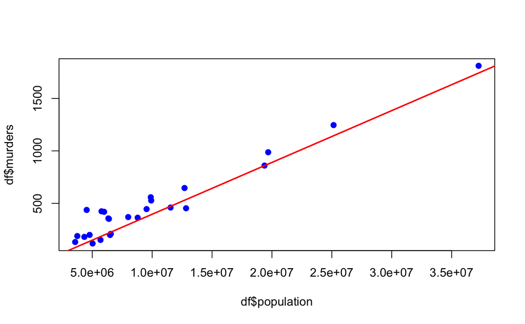

```r
abline(model, col='red', lwd=2)
```